# Beautiful Lesser-Known Visualisations in R

Colour Palettes, Sankey Diagrams, Scatterplots with Marginal Density Plots, Gaussian Graphical Models, Ridge-line plots, Raincloud Plots, Scatterplot Matrices, Caterpillar Plots, Time Series Decomposition Plots, Heatmaps

Joseph Bolton

15 April, 2020

I’ve put together here a little gallery of my favourite lesser-known visualisation methods in R.

Here are all of the packages that I’m going to use:

```r
library(tidyverse)

library(patchwork)      # for arranging ggplots
library(networkD3)    # package for making Sankey diagrams
library(ggalluvial)   # alternative package (addition to ggplot) for making Sankey diagrams
library(ggpubr)       # for scatterplots with marginal density plots
library(ggridges)     # for Ridge-Line plots
library(GGally)        # for making scatterplot matrices, caterpillar plots
library(car)         # for making scatterplot matrices
library(forecast)    # required for ggplot to plot stl() time-series decompositions

library(RColorBrewer)   # for custom colour palettes

# packages needed for Gaussian Graphical Models:
library(correlation)
library(see)
library(ggraph)
library(BayesFactor)
```

Note that I’m really scratching only the very surface of what each of these packages can do. All are worth exploring deeply in their own right.

All of the R code used to create these plots is available at the end of this page.

I also want to highlight the package **patchwork** which is *UNBELIEVABLE* for laying out multiple ggplots: see https://cran.r-project.org/web/packages/patchwork/vignettes/patchwork.html

# Longley’s Economic Regression Data

For some of the examples, I will use the dataset **Longley’s Economic Regression Data**:

| GNP.deflator | GNP | Unemployed | Armed.Forces | Population | Year | Employed |
| --- | --- | --- | --- | --- | --- | --- |
| 83.0 | 234.289 | 235.6 | 159.0 | 107.608 | 1947 | 60.323 |
| 88.5 | 259.426 | 232.5 | 145.6 | 108.632 | 1948 | 61.122 |
| 88.2 | 258.054 | 368.2 | 161.6 | 109.773 | 1949 | 60.171 |
| 89.5 | 284.599 | 335.1 | 165.0 | 110.929 | 1950 | 61.187 |
| 96.2 | 328.975 | 209.9 | 309.9 | 112.075 | 1951 | 63.221 |
| 98.1 | 346.999 | 193.2 | 359.4 | 113.270 | 1952 | 63.639 |
| 99.0 | 365.385 | 187.0 | 354.7 | 115.094 | 1953 | 64.989 |
| 100.0 | 363.112 | 357.8 | 335.0 | 116.219 | 1954 | 63.761 |
| 101.2 | 397.469 | 290.4 | 304.8 | 117.388 | 1955 | 66.019 |
| 104.6 | 419.180 | 282.2 | 285.7 | 118.734 | 1956 | 67.857 |

[output cut: 6 more lines]

# Colour Palettes in R

First off, I want to mention that the package **RColorBrewer** contains the following predefined colour palettes:

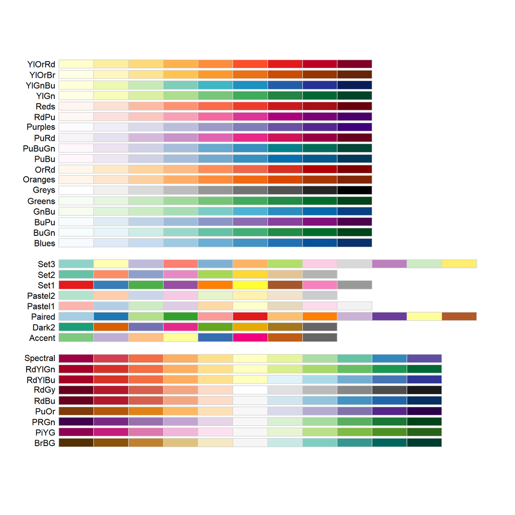

```r
RColorBrewer::display.brewer.all()
```

For example, here are the first 7 colours of the **Dark2** palette used on a base R scatterplot:

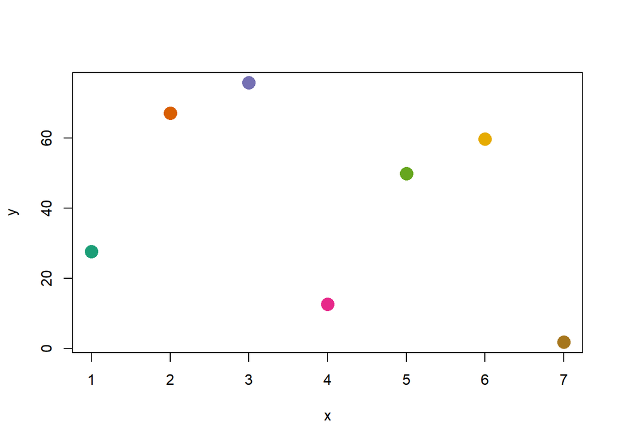

```r
plot(    y = runif(7, 0, 100),
         x = 1:7,
       col = brewer.pal( n=7, name="Dark2"),
       pch = 16,
       cex = 2,
      xlab = "x",
      ylab = "y"
    )
```

# Sankey Diagrams

*Sankey diagrams* are nice for showing quantities flowing between different states (e.g. customers moving between different segments, or money between different entities).

Suppose that we wish to visualise the following data, consisting of customers moving between different activity definitions from one period to the next:

| group | n_customers | year_1 | year_2 | year_3 |
| --- | --- | --- | --- | --- |
| group 1 | 11 | inactive | inactive | active |
| group 2 | 2 | inactive | low activity | inactive |
| group 3 | 17 | active | active | inactive |
| group 4 | 1 | active | highly active | active |
| group 5 | 6 | active | highly active | inactive |
| group 6 | 20 | low activity | active | low activity |
| group 7 | 12 | active | inactive | active |
| group 8 | 19 | low activity | active | active |

Here is a simple *Sankey diagram* visualising this dataset created using the **networkD3** package:

[interactive chart not shown]

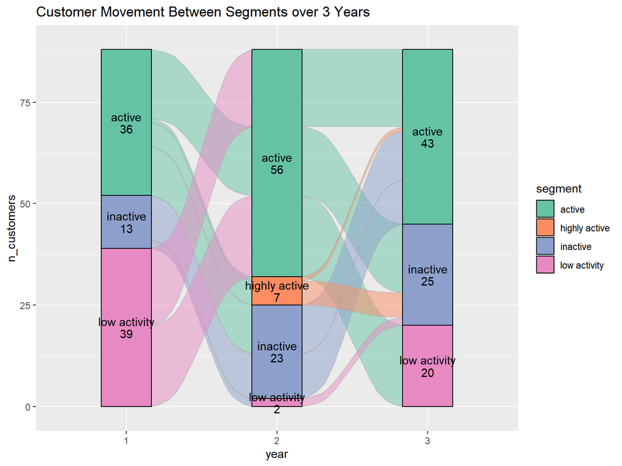

Alternatively, here is the **ggalluvial**-produced equivalent of the **D3** Sankey plot shown earlier. It shows only the flow between subsequent years:

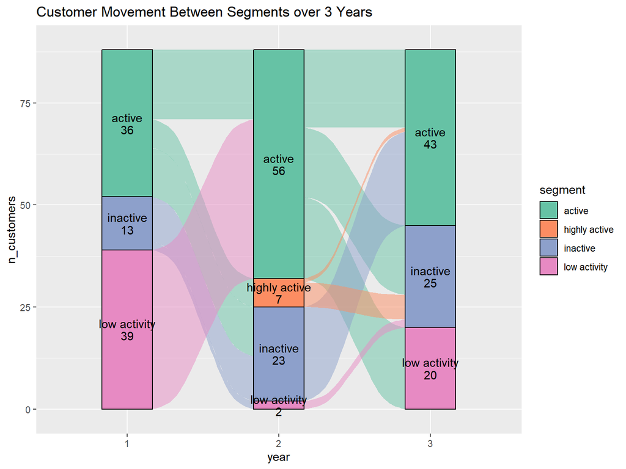

# Scatterplot with Marginal Density Plots

*Scatterplots* illustrate the bivariate distribution of two continuous variables. The addition of *histograms*, *boxplots* or *density* plots on the margins of a *scatterplot* give a nice (additional) view of the univariate distribution of each variable. The marginal univariate distributions are also nice for picking up when points on the *scatterplot* are being plotted on top of one another (*overplotting*). These plots of the **iris** dataset were created using the function **ggscatterhist()** in the **ggpubr** package:

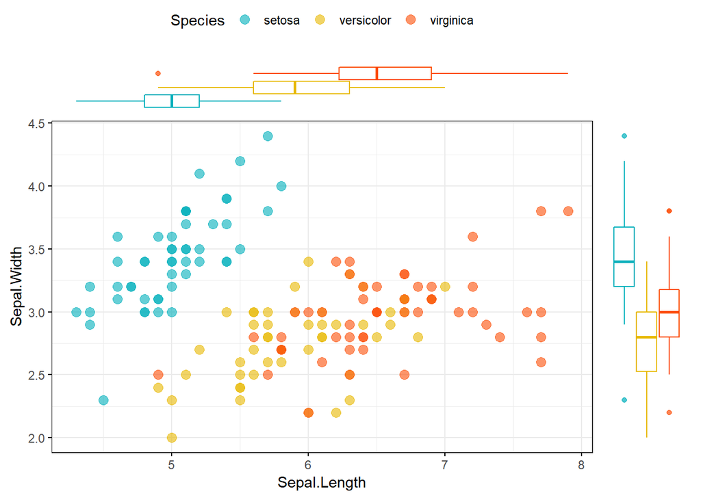

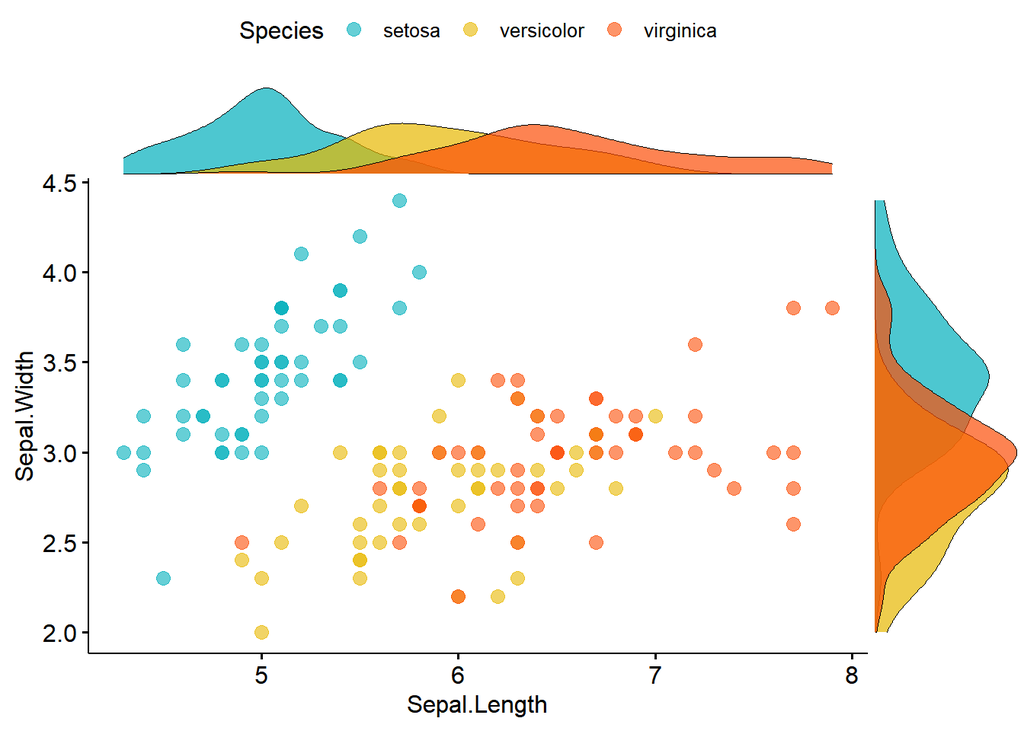

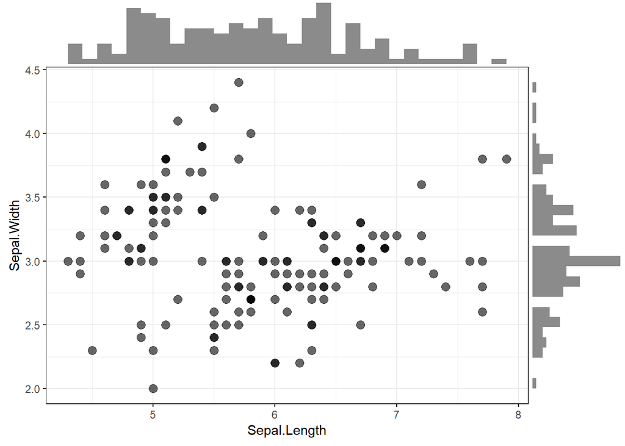

# Gaussian Graphical Models

Visualisations aside, the **correlation** package is very nice for exploring associations between variables in a dataset.

For example:

```r
correlation::correlation(longley)
```

|  | Parameter1 | Parameter2 | r | t | df | p | CI_low | CI_high | Method | n_Obs |
| --- | --- | --- | --- | --- | --- | --- | --- | --- | --- | --- |
| 1 | GNP.deflator | GNP | 0.9915892 | 28.6666337 | 14 | 1.483731e-12 | 0.975258598 | 0.9971563 | Pearson | 16 |
| 2 | GNP.deflator | Unemployed | 0.6206334 | 2.9616055 | 14 | 9.275725e-02 | 0.180440953 | 0.8536976 | Pearson | 16 |
| 3 | GNP.deflator | Armed.Forces | 0.4647442 | 1.9638866 | 14 | 4.183055e-01 | -0.040228929 | 0.7806145 | Pearson | 16 |
| 4 | GNP.deflator | Population | 0.9791634 | 18.0411946 | 14 | 6.491685e-10 | 0.939440452 | 0.9929259 | Pearson | 16 |
| 5 | GNP.deflator | Year | 0.9911492 | 27.9357053 | 14 | 2.006239e-12 | 0.973975486 | 0.9970071 | Pearson | 16 |
| 6 | GNP.deflator | Employed | 0.9708985 | 15.1686953 | 14 | 5.705761e-09 | 0.916087301 | 0.9900925 | Pearson | 16 |
| 7 | GNP | Unemployed | 0.6042609 | 2.8375699 | 14 | 1.053502e-01 | 0.154976576 | 0.8464304 | Pearson | 16 |
| 8 | GNP | Armed.Forces | 0.4464368 | 1.8667693 | 14 | 4.183055e-01 | -0.063270332 | 0.7714249 | Pearson | 16 |
| 9 | GNP | Population | 0.9910901 | 27.8416218 | 14 | 2.006239e-12 | 0.973803160 | 0.9969870 | Pearson | 16 |
| 10 | GNP | Year | 0.9952735 | 38.3472883 | 14 | 2.930564e-14 | 0.986046288 | 0.9984039 | Pearson | 16 |

[output cut: 11 more lines]

..including Bayesian measures of association:

```r
correlation::correlation(longley, bayesian=TRUE)
```

|  | Parameter1 | Parameter2 | rho | CI_low | CI_high | pd | ROPE_Percentage | BF | Prior_Distribution | Prior_Location | Prior_Scale | n_Obs |
| --- | --- | --- | --- | --- | --- | --- | --- | --- | --- | --- | --- | --- |
| 1 | GNP.deflator | GNP | 0.9780754 | 0.95943049 | 0.9914253 | 1.00000 | 0.00000 | NA | cauchy | 0 | 0.3333333 | 16 |
| 2 | GNP.deflator | Unemployed | 0.4648775 | 0.19571234 | 0.7526600 | 0.98625 | 0.03575 | 5.909442e+00 | cauchy | 0 | 0.3333333 | 16 |
| 3 | GNP.deflator | Armed.Forces | 0.3376841 | 0.03050577 | 0.6535052 | 0.93000 | 0.10500 | 1.776117e+00 | cauchy | 0 | 0.3333333 | 16 |
| 4 | GNP.deflator | Population | 0.9475681 | 0.90341517 | 0.9787181 | 1.00000 | 0.00000 | 9.577355e+05 | cauchy | 0 | 0.3333333 | 16 |
| 5 | GNP.deflator | Year | 0.9788334 | 0.95288623 | 0.9891933 | 1.00000 | 0.00000 | NA | cauchy | 0 | 0.3333333 | 16 |
| 6 | GNP.deflator | Employed | 0.9255808 | 0.85153693 | 0.9756322 | 1.00000 | 0.00000 | 2.426657e+05 | cauchy | 0 | 0.3333333 | 16 |
| 7 | GNP | Unemployed | 0.4558377 | 0.17845952 | 0.7385760 | 0.98150 | 0.05250 | 5.049784e+00 | cauchy | 0 | 0.3333333 | 16 |
| 8 | GNP | Armed.Forces | 0.3162209 | -0.01506724 | 0.6436701 | 0.93225 | 0.13425 | 1.598492e+00 | cauchy | 0 | 0.3333333 | 16 |
| 9 | GNP | Population | 0.9767147 | 0.95494295 | 0.9893581 | 1.00000 | 0.00000 | NA | cauchy | 0 | 0.3333333 | 16 |
| 10 | GNP | Year | 0.9888516 | 0.96917266 | 0.9946416 | 1.00000 | 0.00000 | NA | cauchy | 0 | 0.3333333 | 16 |

[output cut: 11 more lines]

..and here is a Guassian Graphical Model to visualise these correlations:

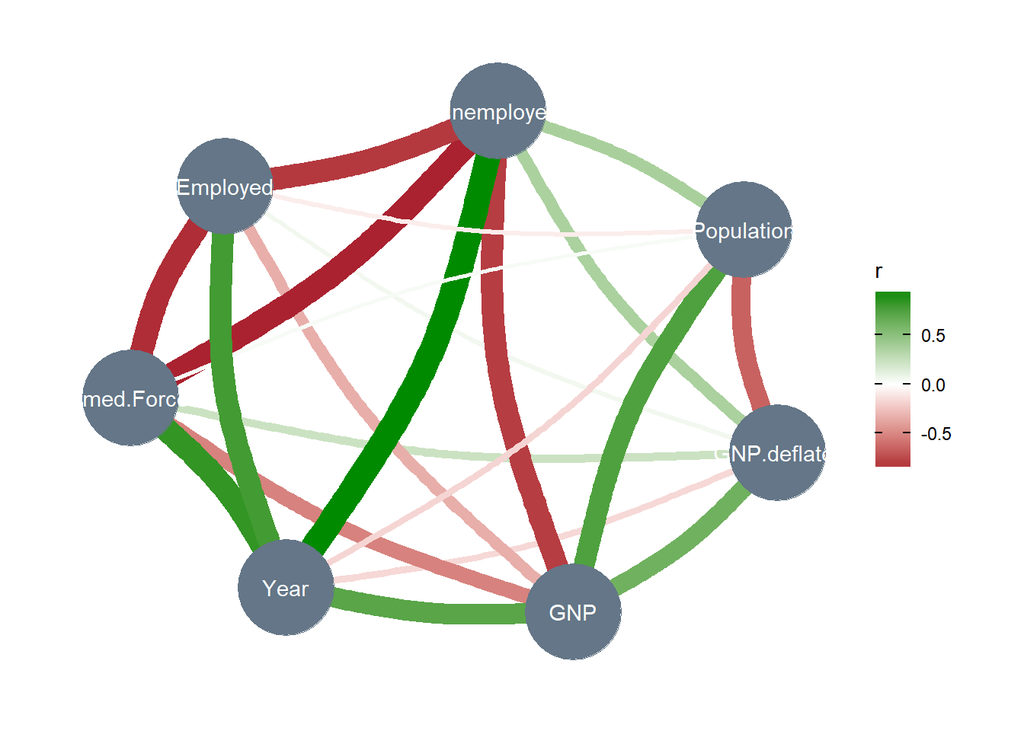

```r
longley %>%
  correlation(partial = TRUE) %>%
  plot()
```

# Ridge-Line Plots

*Ridge-line plots* are a convenient way to plot more than one univariate density on the same plot. Here are four different ways to display the distribution of *sepal-length* between different *species* (data from the **iris** dataset) using the package **ggridges**:

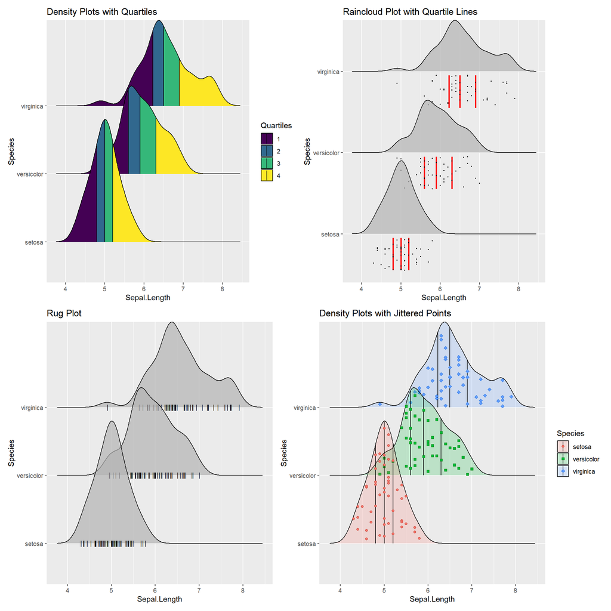

# Raincloud Plots

Similar to a *ridge-line plot*, a *raincloud plot* allows one to visually contrast the distributions of several different univariate continuous variables. It is a *density*, *scatter* and *box plot*, all on the same plot:

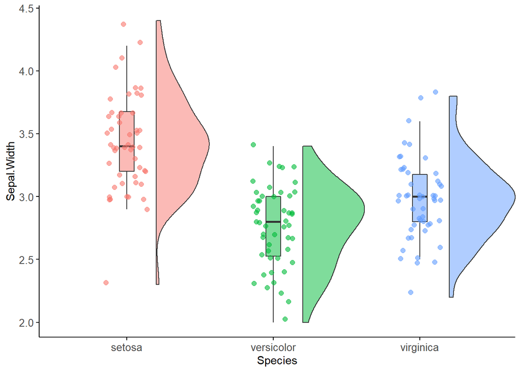

# Scatterplot Matrices

*Scatterplot matrices* are a quick way to plot the bivariate relationships between all pairs of variables in a dataset. Here are four alternative views of the **iris** dataset, using the packages **car** and **GGally**:

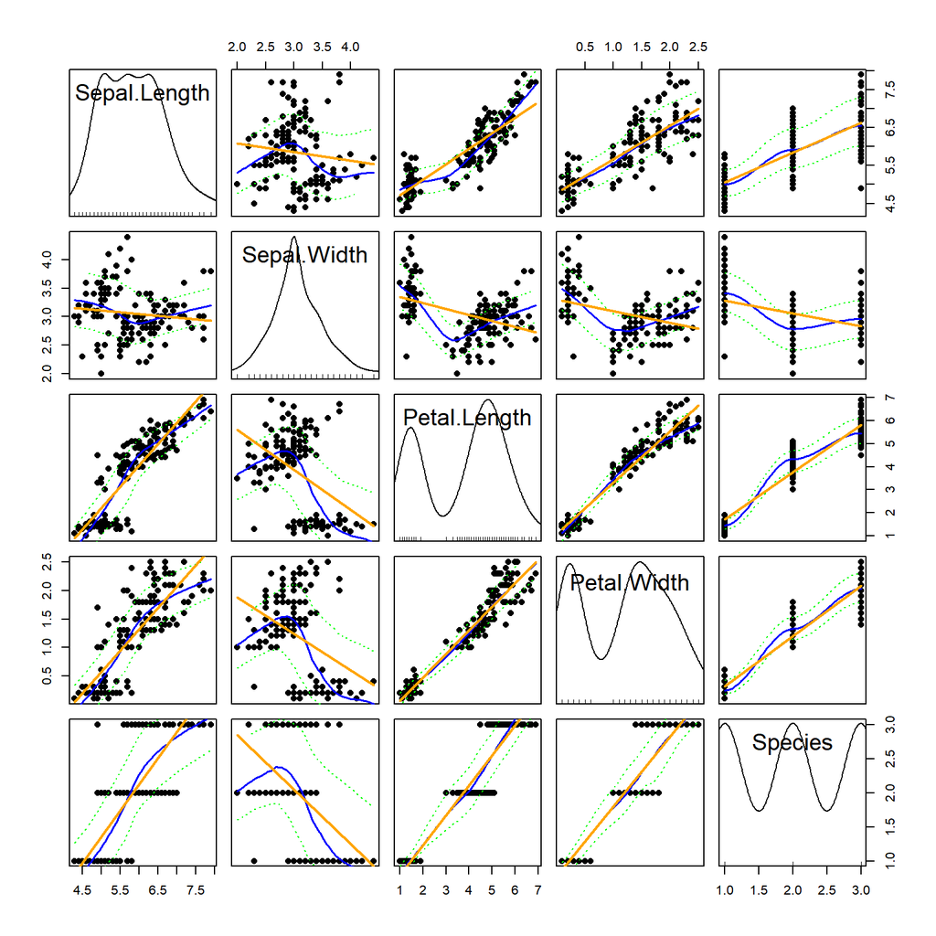

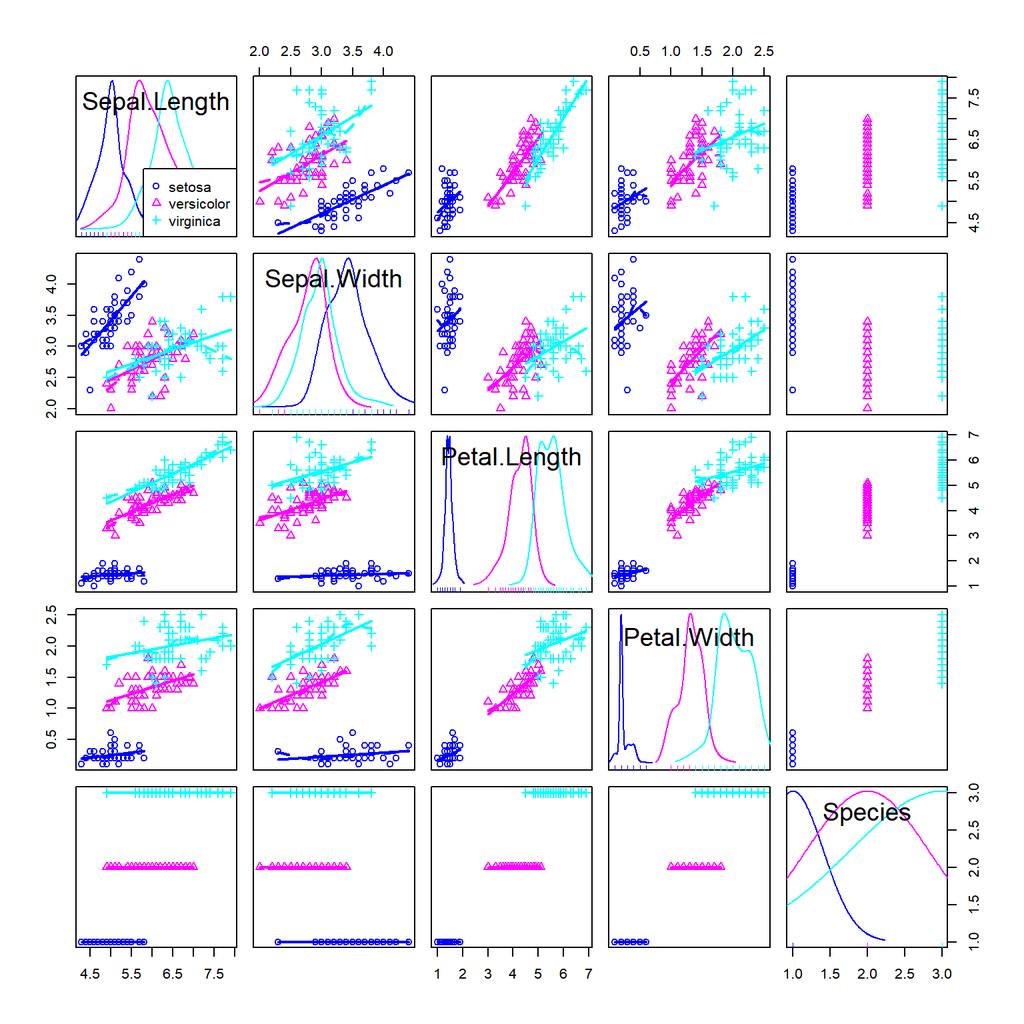

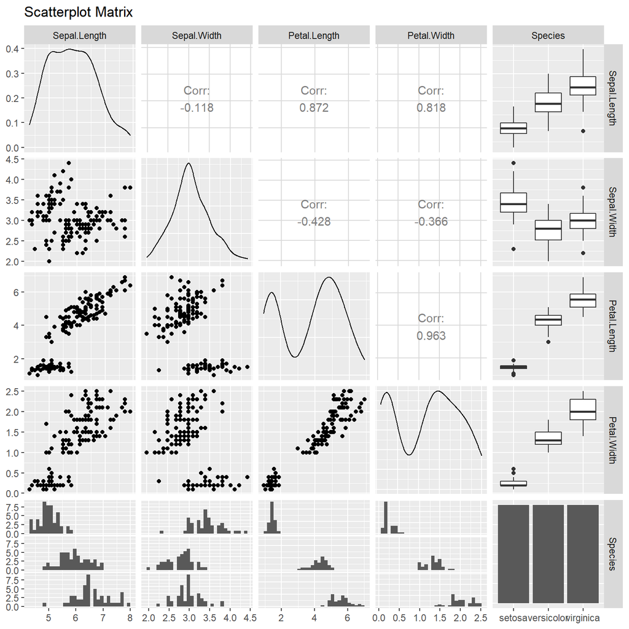

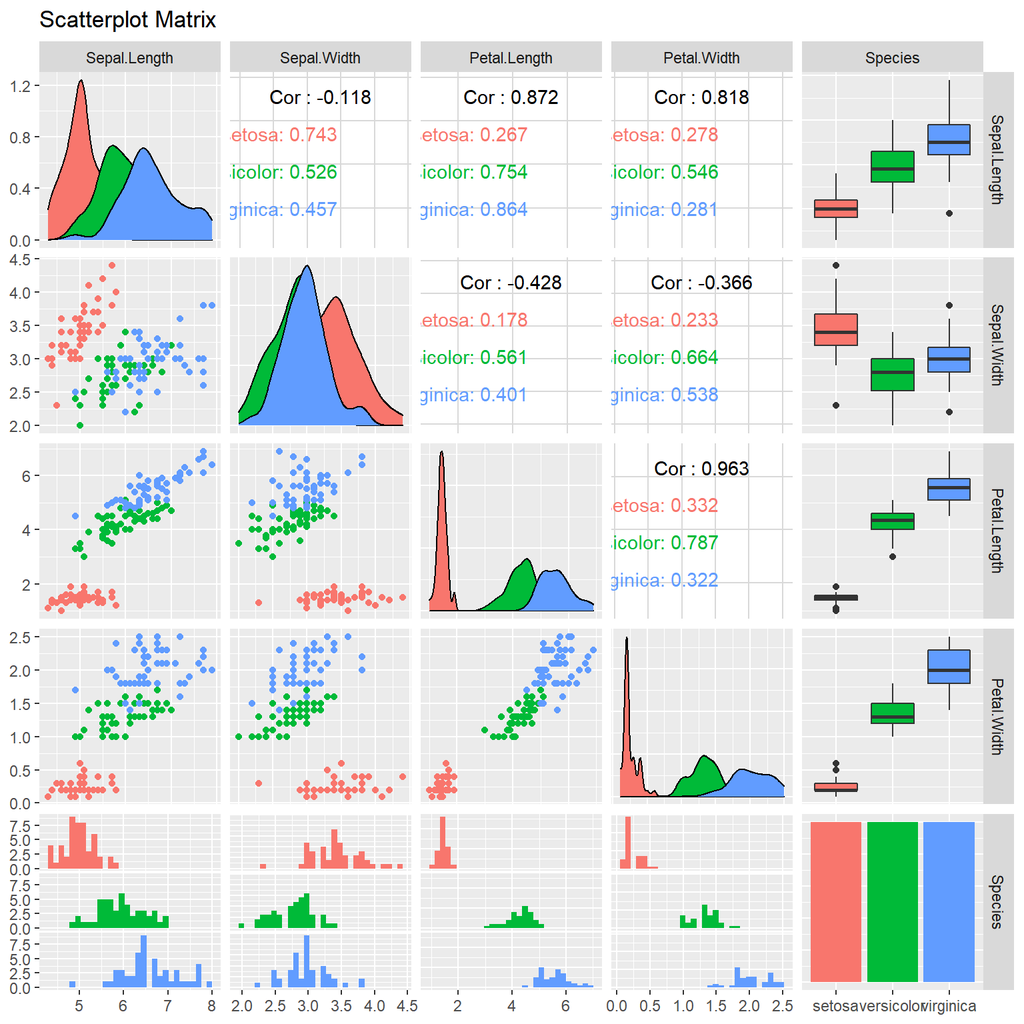

# Caterpillar Plots

A *caterpillar plot* is a nice way to visualise the coefficients and confidence intervals of the parameter/coefficient estimates of a model. For example:

```r
fit_linear_model <- lm( Sepal.Length ~ Sepal.Width + Petal.Length + Petal.Width, data = iris )
cbind( estimate=coef(fit_linear_model), confint(fit_linear_model) )
```

```
##                estimate      2.5 %     97.5 %
## (Intercept)   1.8559975  1.3603752  2.3516197
## Sepal.Width   0.6508372  0.5191189  0.7825554
## Petal.Length  0.7091320  0.5970350  0.8212289
## Petal.Width  -0.5564827 -0.8085615 -0.3044038
```

```r
ggcoef(
  fit_linear_model,
  vline_color = "red",
  vline_linetype =  "solid",
  errorbar_color = "blue",
  errorbar_height = .25
)
```

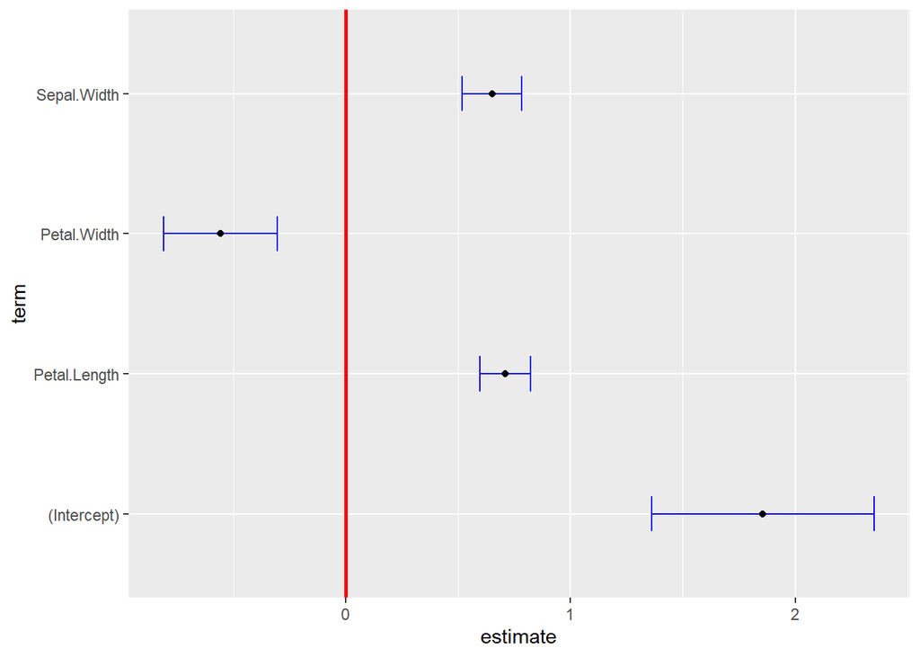

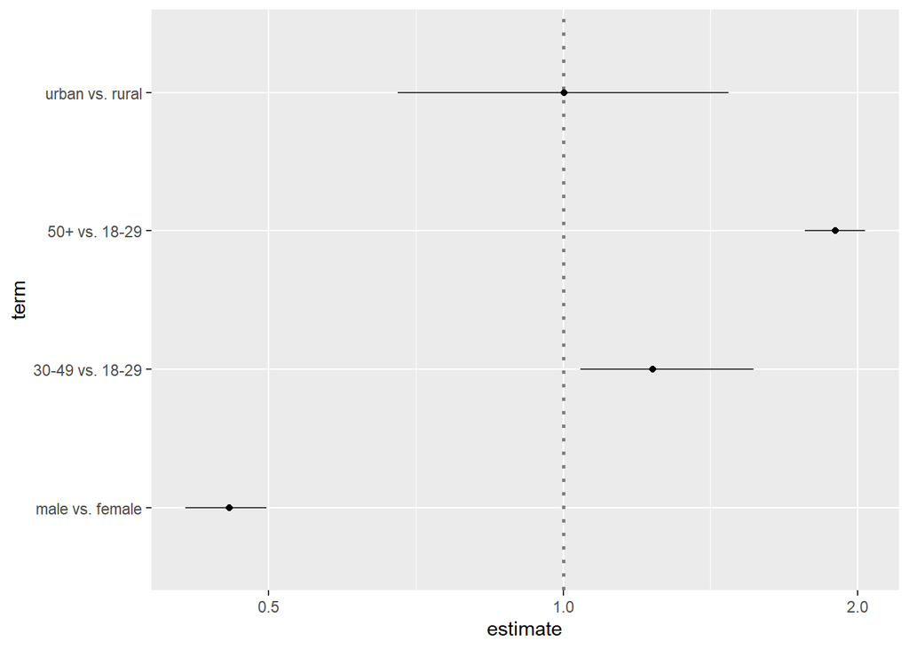

```r
# or using a custom data frame instead of a model:
cust <- data.frame(
  term = c("male vs. female", "30-49 vs. 18-29", "50+ vs. 18-29", "urban vs. rural"),
  estimate = c(.456, 1.234, 1.897, 1.003),
  conf.low = c(.411, 1.042, 1.765, 0.678),
  conf.high = c(.498, 1.564, 2.034, 1.476),
  variable = c("sex", "age", "age", "residence")
)
cust$term <- factor(cust$term, cust$term)
ggcoef(cust, exponentiate = TRUE)
```

If customisation of the plot is required outside of the scope of the **GGally::ggcoef()** function, then these plots can be created from scratch in **ggplot2** using the functions **geom_point()** and **geom_errorbar()**.

# Time Series Decomposition Plots

This is technically more a statistical than a data visualistion method, but I love the idea of trying to break a univariate time series into component parts, here using the function **stl** and plotting with base R:

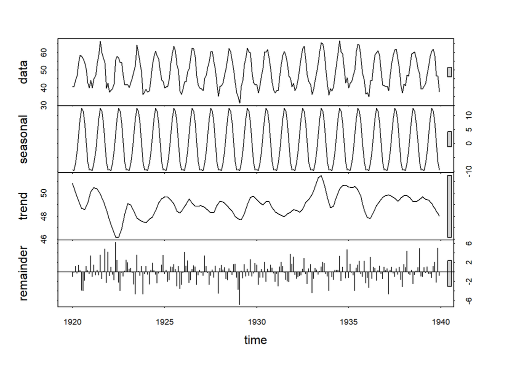

```r
stl( nottem,
     t.window = 13,
     s.window = "periodic",
       robust = TRUE
    ) %>%
  plot()
```

An alternative is to plot the output of the **stl** function using the **ggplot2** package (note that this also requires Rob Hyndman’s **forecast** package to be loaded):

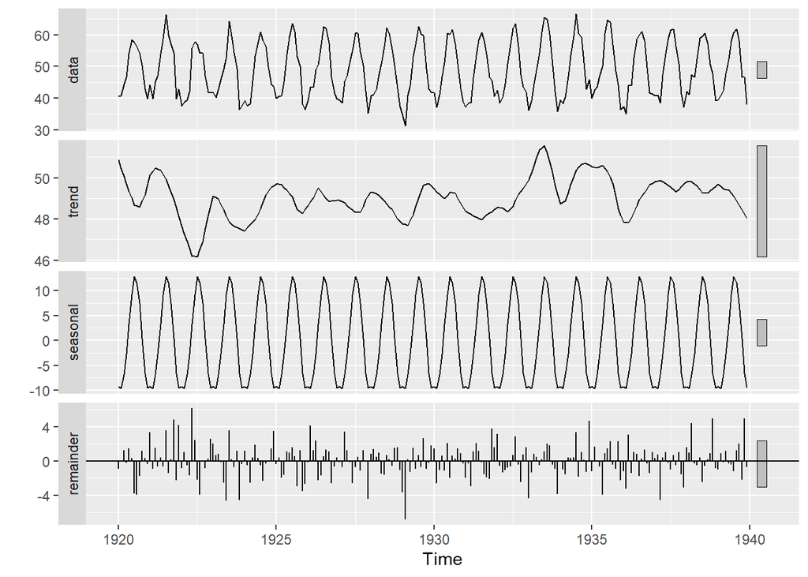

```r
nottem %>%
  stl( nottem,
       t.window = 13,
       s.window = "periodic",
         robust = TRUE
      ) %>%
  ggplot2::autoplot()
```

# Heatmaps

*Heatmaps* show the value of a continuous variable cross-tabulated across two categorical variables. Here is a simple *heatmap* of the distribution of the variable *avg_unemployed* by *decade* and *armed_forces* quintile, from the **Longley** dataset. The plot is created using *geom_tile()* from the **ggplot2** package:

| decade | armed_forces_quintile | avg_unemployed |
| --- | --- | --- |
| 1940's | 1 | 278.7667 |
| 1950's | 1 | 335.1000 |
| 1950's | 2 | 381.3000 |
| 1950's | 3 | 380.8500 |
| 1950's | 4 | 260.8333 |
| 1950's | 5 | 246.0000 |
| 1960's | 2 | 436.8500 |
| 1960's | 3 | 400.7000 |

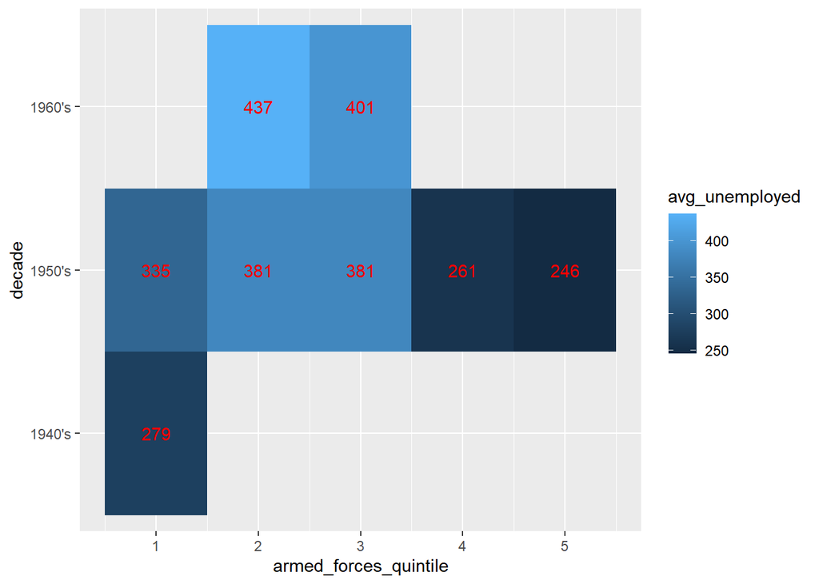

# Resources

- https://github.com/easystats/correlation
- http://jianchen.info/RainCloud_Plot_in_R/
- https://cran.r-project.org/web/packages/ggridges/vignettes/introduction.html
- https://ggobi.github.io/ggally/
- https://data.library.virginia.edu/setting-up-color-palettes-in-r/
- https://cran.r-project.org/web/packages/ggalluvial/vignettes/ggalluvial.html
- https://otexts.com/fpp2/decomposition.html

# Appendix: Code for all Plots

```r
#########################
# DATA FOR SANKEY PLOTS #
#########################

# create data for Sankey example:
data_for_sankey <-
  bind_rows(
              tibble( group = "group 1", year = 1, segment = "inactive" ),
              tibble( group = "group 1", year = 2, segment = "inactive" ),
              tibble( group = "group 1", year = 3, segment = "active" ),

              tibble( group = "group 2", year = 1, segment = "inactive" ),
              tibble( group = "group 2", year = 2, segment = "low activity" ),
              tibble( group = "group 2", year = 3, segment = "inactive" ),

              tibble( group = "group 3", year = 1, segment = "active" ),
              tibble( group = "group 3", year = 2, segment = "active" ),
              tibble( group = "group 3", year = 3, segment = "inactive" ),

              tibble( group = "group 4", year = 1, segment = "active" ),
              tibble( group = "group 4", year = 2, segment = "highly active" ),
              tibble( group = "group 4", year = 3, segment = "active" ),

              tibble( group = "group 5", year = 1, segment = "active" ),
              tibble( group = "group 5", year = 2, segment = "highly active" ),
              tibble( group = "group 5", year = 3, segment = "inactive" ),

              tibble( group = "group 6", year = 1, segment = "low activity" ),
              tibble( group = "group 6", year = 2, segment = "active" ),
              tibble( group = "group 6", year = 3, segment = "low activity" ),

              tibble( group = "group 7", year = 1, segment = "active" ),
              tibble( group = "group 7", year = 2, segment = "inactive" ),
              tibble( group = "group 7", year = 3, segment = "active" ),

              tibble( group = "group 8", year = 1, segment = "low activity" ),
              tibble( group = "group 8", year = 2, segment = "active" ),
              tibble( group = "group 8", year = 3, segment = "active" )
          ) %>%
    mutate( year = factor(year) ) %>%
    left_join(
               bind_rows( tibble(group="group 1", n_customers=11),
                          tibble(group="group 2", n_customers=2),
                          tibble(group="group 3", n_customers=17),
                          tibble(group="group 4", n_customers=1),
                          tibble(group="group 5", n_customers=6),
                          tibble(group="group 6", n_customers=20),
                          tibble(group="group 7", n_customers=12),
                          tibble(group="group 8", n_customers=19)
                       ),
               by = "group"
             )

# display data for Sankey in wide format:
data_for_sankey %>%
  pivot_wider( id_cols = c(group, n_customers), names_from=year, values_from = segment, names_prefix="year_" )

###################################
# SANKEY DIAGRAM using D3 PACKAGE #
###################################

# put the data for Sankey plot in convenient format for function networkD3::sankeyNetwork():
text_links_data <-
  bind_rows(
             tibble( source_period = 1, source_status="active",
                     target_period = 2, target_status="active",
                       n_customers = 17
                  ),
             tibble( source_period = 1, source_status="active",
                     target_period = 2, target_status="highly_active",
                       n_customers = 7
                  ),
             tibble( source_period = 1, source_status="active",
                     target_period = 2, target_status="inactive",
                       n_customers = 12
                  )
             ,
             tibble( source_period = 1, source_status="inactive",
                     target_period = 2, target_status="inactive",
                       n_customers = 11

                  ),
             tibble( source_period = 1, source_status="inactive",
                     target_period = 2, target_status="low_activity",
                       n_customers = 2
                  ),
             tibble( source_period = 1, source_status="low_activity",
                     target_period = 2, target_status="active",
                       n_customers = 39
                  )
             ,

             tibble( source_period = 2, source_status="active",
                     target_period = 3, target_status="active",
                       n_customers = 19
                  ),
             tibble( source_period = 2, source_status="active",
                     target_period = 3, target_status="inactive",
                       n_customers = 17
                  ),
             tibble( source_period = 2, source_status="active",
                     target_period = 3, target_status="low_activity",
                       n_customers = 20
                  ),
             tibble( source_period = 2, source_status="highly_active",
                     target_period = 3, target_status="active",
                       n_customers = 1
                  )
             ,
             tibble( source_period = 2, source_status="highly_active",
                     target_period = 3, target_status="inactive",
                       n_customers = 6
                  ),
             tibble( source_period = 2, source_status="inactive",
                     target_period = 3, target_status="active",
                       n_customers = 23
                  ),
             tibble( source_period = 2, source_status="low_activity",
                     target_period = 3, target_status="inactive",
                       n_customers = 2
                  )
  )

# each node needs to be given assigned a node number 0,1,2,.... (node indexing must start at 0)
node_numbers <-
  bind_rows(
             # source nodes
             text_links_data %>%
               distinct(source_period, source_status) %>%
               rename( period = source_period,
                       node_status = source_status
                     )
             ,
             # target nodes
             text_links_data %>%
               distinct(target_period, target_status) %>%
               rename( period = target_period,
                       node_status = target_status
                     )
    ) %>%
  distinct( period, node_status ) %>%
  arrange( node_status ) %>%
  mutate( node_number = row_number()-1 )
```

```r
# define colours of the nodes (based on node status):
define_palette_for_nodes <-
  RColorBrewer::brewer.pal( n=length(unique(node_numbers$node_status)), name="Set1" ) # see RColorBrewer::display.brewer.all() for other palette options

node_colours <- tibble( node_status = unique(node_numbers$node_status),
                        node_colour = define_palette_for_nodes
                      )

# define node information in format required by the function networkD3::sankeyNetwork()
links_data <-
  text_links_data %>%
    left_join( node_numbers, by=c("source_period"="period", "source_status"="node_status") ) %>%
      rename( source_node = node_number ) %>%
    left_join( node_numbers, by=c("target_period"="period", "target_status"="node_status") ) %>%
      rename( target_node = node_number )

# make the D3 sankey plot:
networkD3::sankeyNetwork(     Links = as.data.frame(links_data),
                              Nodes = as.data.frame(node_numbers),
                             Source = "source_node",
                             Target = "target_node",
                              Value = "n_customers",
                             NodeID = "node_status",
                          LinkGroup = "source_status",
                          NodeGroup = "node_status",
                           fontSize = 20,
                         iterations = 0,
                        nodePadding = 20,  # controls separation of nodes
                        # set custom node colours:
                        colourScale = JS(
                                          paste0("d3.scaleOrdinal()
                                                    .domain([",
                                                              paste(
                                                                     paste("\"", node_colours$node_status, "\"", sep=""),
                                                                     collapse=", "
                                                                   ),
                                                            "])
                                                    .range([",
                                                              paste(
                                                                     paste("\"", node_colours$node_colour, "\"", sep=""),
                                                                     collapse=", "
                                                                   ),
                                                            "])"
                                                )
                                        )
)


#############################################
# SANKEY DIAGRAM using ggplot2 & ggalluvial #
#############################################

ggplot( data = data_for_sankey,
          aes(       x = year,
                     y = n_customers,
               stratum = segment,
               alluvium = group,
                   fill = segment
             )
        ) +
    geom_flow( stat = "alluvium",
               lode.guidance = "frontback",
               colour = "darkgray"
             ) +
    scale_fill_brewer( type="qual", palette="Set2" ) +
    geom_stratum() +
    geom_text( aes(label=segment), stat="stratum", nudge_y=1.5 ) +
    geom_text( aes(label=n_customers), stat="stratum", nudge_y=-1.5) +
    labs( title = "Customer Movement Between Segments over 3 Years")

ggplot( data = data_for_sankey,
          aes(       x = year,
                     y = n_customers,
               stratum = segment,
               alluvium = group,
                   fill = segment
             )
        ) +
    geom_flow() +
    scale_fill_brewer( type="qual", palette="Set2" ) +
    geom_stratum() +
    geom_text( aes(label=segment), stat="stratum", nudge_y=1.5 ) +
    geom_text( aes(label=n_customers), stat="stratum", nudge_y=-1.5) +
    labs( title = "Customer Movement Between Segments over 3 Years")


########################################
# SCATTERPLOT + MARGINAL DENSITY PLOTS #
########################################

ggscatterhist(
 iris, x = "Sepal.Length", y = "Sepal.Width",
 color = "Species", size = 3, alpha = 0.6,
 palette = c("#00AFBB", "#E7B800", "#FC4E07"),
 margin.plot = "boxplot",
 ggtheme = theme_bw()
)

ggscatterhist(
 iris, x = "Sepal.Length", y = "Sepal.Width",
 color = "Species", size = 3, alpha = 0.6,
 palette = c("#00AFBB", "#E7B800", "#FC4E07"),
 margin.params = list(fill = "Species", color = "black", size = 0.2)
)

ggscatterhist(
 iris, x = "Sepal.Length", y = "Sepal.Width",
 size = 3, alpha = 0.6,
 margin.plot = "histogram",
 ggtheme = theme_bw()
)



#####################
# RIDGE-LINE PLOTS  #
#####################
plot1 <-
  ggplot(iris, aes(x=Sepal.Length, y=Species, fill = factor(stat(quantile)))) +
    stat_density_ridges(
      geom = "density_ridges_gradient", calc_ecdf = TRUE,
      quantiles = 4, quantile_lines = TRUE,
      bandwidth = 0.181
    ) +
    scale_fill_viridis_d(name = "Quartiles") +
    labs( title = "Density Plots with Quartiles" )

plot2 <-
  ggplot(iris, aes(x = Sepal.Length, y = Species)) +
    geom_density_ridges(
             jittered_points = TRUE,
             quantile_lines = TRUE,
             scale = 0.9,
             alpha = 0.7,
             vline_size = 1, vline_color = "red",
             point_size = 0.4, point_alpha = 1,
             position = position_raincloud(adjust_vlines = TRUE),
             bandwidth = 0.181
    ) +
    labs( title = "Raincloud Plot with Quartile Lines" )

plot3 <-
  ggplot(iris, aes(x = Sepal.Length, y = Species)) +
    geom_density_ridges(
      jittered_points = TRUE,
      position = position_points_jitter(width = 0.05, height = 0),
      point_shape = '|', point_size = 3, point_alpha = 1, alpha = 0.7,
      bandwidth = 0.181
    ) +
  labs( title = "Rug Plot")

plot4 <-
  ggplot(iris, aes(x = Sepal.Length, y = Species, fill = Species)) +
    geom_density_ridges(
      aes(point_color = Species, point_fill = Species, point_shape = Species),
      alpha = .2, point_alpha = 1, jittered_points = TRUE,
      bandwidth = 0.181,
      quantile_lines = TRUE, quantiles=4
    ) +
    scale_point_color_hue(l = 40) +
    scale_discrete_manual(aesthetics = "point_shape", values = c(21, 22, 23)) +
    labs( title = "Density Plots with Jittered Points" )
```

```r
( plot1 + plot2 ) / ( plot3 + plot4 )      # this requires package [patchwork]



###################
# RAINCLOUD PLOTS #
###################
# function from http://jianchen.info/RainCloud_Plot_in_R/

# =========================== START function definition ===========================

## define function of geom_flat_volin
# devtools::install_github(repo = "IndrajeetPatil/ggstatsplot")

"%||%" <- function(a, b) {
 if (!is.null(a))
     a
 else
     b
    }

geom_flat_violin <-
 function(mapping = NULL,
        data = NULL,
        stat = "ydensity",
        position = "dodge",
        trim = TRUE,
        scale = "area",
        show.legend = NA,
        inherit.aes = TRUE,
        ...) {
ggplot2::layer(
 data = data,
 mapping = mapping,
 stat = stat,
 geom = GeomFlatViolin,
 position = position,
 show.legend = show.legend,
 inherit.aes = inherit.aes,
 params = list(trim = trim,
                scale = scale,
                ...)
)
  }

GeomFlatViolin <-
  ggproto(
"GeomFlatViolin",
Geom,
setup_data = function(data, params) {
  data$width <- data$width %||%
    params$width %||% (resolution(data$x, FALSE) * 0.9)

# ymin, ymax, xmin, and xmax define the bounding rectangle for each group
data %>%
    dplyr::group_by(.data = ., group) %>%
    dplyr::mutate(
      .data = .,
      ymin = min(y),
      ymax = max(y),
      xmin = x,
      xmax = x + width / 2
    )
},

draw_group = function(data, panel_scales, coord)
{
# Find the points for the line to go all the way around
data <- base::transform(data,
                          xminv = x,
                          xmaxv = x + violinwidth * (xmax - x))

# Make sure it's sorted properly to draw the outline
newdata <-
    base::rbind(
      dplyr::arrange(.data = base::transform(data, x = xminv), y),
      dplyr::arrange(.data = base::transform(data, x = xmaxv), -y)
    )

# Close the polygon: set first and last point the same
# Needed for coord_polar and such
 newdata <- rbind(newdata, newdata[1,])

  ggplot2:::ggname("geom_flat_violin",
                   GeomPolygon$draw_panel(newdata, panel_scales, coord))
},

draw_key = draw_key_polygon,

default_aes = ggplot2::aes(
  weight = 1,
  colour = "grey20",
  fill = "white",
  size = 0.5,
  alpha = NA,
  linetype = "solid"
),

required_aes = c("x", "y")
  )
# =========================== END function definition ===========================

# make rain-cloud plot:
ggplot(data = iris, aes(y = Sepal.Width, x = Species, fill = Species)) +
  geom_flat_violin(position = position_nudge(x = .2, y = 0), alpha = .5) +
  geom_boxplot(width = .1,  outlier.shape = NA, alpha = 0.5) +
  geom_point( aes(y = Sepal.Width, color = Species),
              position = position_jitter(width = .15), size = 2, alpha = 0.6) +

  theme(legend.position="none") + theme(axis.title = element_text(family = "Times New Roman")) +
  theme(axis.text=element_text(size=10, family = "Times New Roman")) +
  theme(legend.title = element_text(family = "Times New Roman")) +
  theme(panel.grid.major = element_blank(), panel.grid.minor = element_blank()) + theme(panel.background = element_blank()) +
  #theme(panel.border = element_rect(color = 'black',fill=NA, size = 1)) +
  theme(axis.line = element_line(colour = 'black', size = 0.5)) +
  theme(axis.ticks = element_line(colour = "black", size = 0.4))



########################
# SCATTERPLOT MATRICES #
########################

car::scatterplotMatrix(   x = iris,    # data to be plotted
                        pch = 16,       # point type
                        col = "black",   # point colour
                        # settings of fitted lines:
                        smooth = list( smoother=loessLine,
                                       spread=TRUE,
                                       lty.smooth=1,
                                       lwd.smooth=1.5,
                                       lty.spread=3,
                                       lwd.spread=1,
                                       col.smooth = "blue",
                                       col.spread = "green"
                                      ),
                        regLine = list(col="orange")
                        )

# plot by groups:
car::scatterplotMatrix( x = iris,    # data to be plotted
                        by.groups = TRUE,    # fitted lines fit by group
                        groups = iris$Species,
                        legend = list(coords="bottomright")
                      )

# Slower function, but very nice:
# for extensive plot customisation, see https://ggobi.github.io/ggally/
GGally::ggpairs( iris,
                 title = "Scatterplot Matrix",
                 progress = FALSE
               )

GGally::ggpairs( iris,
                 title = "Scatterplot Matrix",
                 progress = FALSE,
                 mapping = ggplot2::aes(colour = Species)
               )



###########
# HEATMAP #
###########

data_for_heatmap <-
  longley %>%
    mutate( decade = paste0( "19", floor( (Year-1900)/10 )*10, "'s" ) ) %>%
    mutate( armed_forces_quintile = ntile(Armed.Forces, n=5) ) %>%
    group_by( decade, armed_forces_quintile ) %>%
    summarise( avg_unemployed = mean(Unemployed) )

#The data for the heatmap plot look like this:
data_for_heatmap

# make the heatmap:
ggplot(   data = data_for_heatmap,
        aes(     x = armed_forces_quintile,
                 y = decade,
              fill = avg_unemployed,
             label = round(avg_unemployed)
           )
      ) +
  geom_tile() +
  geom_text( colour = "red" )               # add the labels to each cell
```